# Data cleaning and descriptive statistics for CIND820

```r
library(foreign)
```

```r
brfss_data <- read.xport("C:/Users/mmkea/Documents/2015_raw_data.xpt")
```

[output not shown]

First, limit the data to our age groups of interest (eg, 60 years and older).

```r
unique(brfss_data$X_AGEG5YR) #9-13 is 60-80+ ; 14 is refused or don't know
```

```
 [1]  9  7 11 13 10 12  8  4  6  2  3  5  1 14
```

```r
brfss_data_60YR <- subset(brfss_data, brfss_data$X_AGEG5YR > 8 & brfss_data$X_AGEG5YR < 14)
head(brfss_data_60YR) #202412 individuals
```

|  | X_STATE | FMONTH | IDATE | IMONTH | IDAY | IYEAR | DISPCODE | SEQNO | X_PSU | CTELENUM | PVTRESD1 | COLGHOUS | STATERES | CELLFON3 | LADULT | NUMADULT | NUMMEN | NUMWOMEN | CTELNUM1 | CELLFON2 | CADULT | PVTRESD2 | CCLGHOUS | CSTATE | LANDLINE | HHADULT | GENHLTH | PHYSHLTH | MENTHLTH | … |
| --- | --- | --- | --- | --- | --- | --- | --- | --- | --- | --- | --- | --- | --- | --- | --- | --- | --- | --- | --- | --- | --- | --- | --- | --- | --- | --- | --- | --- | --- | --- |
| 1 | 1 | 1 | 01292015 | 01 | 29 | 2015 | 1200 | 2.015e+09 | 2.015e+09 | 1 | 1 | NA | 1 | 2 | NA | 3 | 1 | 2 | NA | NA | NA | NA | NA | NA | NA | NA | 5 | 15 | 18 | … |
| 3 | 1 | 1 | 02012015 | 02 | 01 | 2015 | 1200 | 2.015e+09 | 2.015e+09 | 1 | 1 | NA | 1 | 2 | NA | 2 | 1 | 1 | NA | NA | NA | NA | NA | NA | NA | NA | 4 | 15 | 88 | … |
| 4 | 1 | 1 | 01142015 | 01 | 14 | 2015 | 1100 | 2.015e+09 | 2.015e+09 | 1 | 1 | NA | 1 | 2 | NA | 3 | 1 | 2 | NA | NA | NA | NA | NA | NA | NA | NA | 5 | 30 | 30 | … |
| 5 | 1 | 1 | 01142015 | 01 | 14 | 2015 | 1100 | 2.015e+09 | 2.015e+09 | 1 | 1 | NA | 1 | 2 | NA | 2 | 1 | 1 | NA | NA | NA | NA | NA | NA | NA | NA | 5 | 20 | 88 | … |
| 6 | 1 | 1 | 01142015 | 01 | 14 | 2015 | 1100 | 2.015e+09 | 2.015e+09 | 1 | 1 | NA | 1 | 2 | NA | 1 | 0 | 1 | NA | NA | NA | NA | NA | NA | NA | NA | 2 | 88 | 88 | … |
| 7 | 1 | 1 | 01052015 | 01 | 05 | 2015 | 1100 | 2.015e+09 | 2.015e+09 | 1 | 1 | NA | 1 | 2 | NA | 1 | 0 | 1 | NA | NA | NA | NA | NA | NA | NA | NA | 2 | 88 | 3 | … |

```r
data <- subset(brfss_data_60YR,
               select=c(SEX, MARITAL,NUMADULT, HHADULT, CHILDREN,
                        X_RACE,
             X_AGEG5YR, X_BMI5, X_EDUCAG, EMPLOY1, INCOME2, RENTHOM1, VETERAN3, X_RFHLTH,
             PHYSHLTH, MENTHLTH, HLTHPLN1, MEDCOST, CHECKUP1, X_RFHYPE5,
             X_RFCHOL, X_MICHD, CVDSTRK3, X_ASTHMS1, CHCSCNCR, CHCOCNCR,
             CHCCOPD1, X_DRDXAR1, ADDEPEV2, CHCKIDNY, DIABETE3, X_SMOKER3,
             QLACTLM2, USEEQUIP, BLIND, DECIDE, ALCDAY5, AVEDRNK2,
              X_FRUTSUM, BEANDAY_, X_VEGESUM, PA1MIN_, EXRACT11,
             STRENGTH, PA1VIGM_, FLUSHOT6))
```

Reducing the HHADULT and NUMADULT variables to one ADULT variable.

```r
unique(data$HHADULT)
```

```
 [1] NA  1  2  3  4  5  6 12  7 77 99 14  8  9 10 13 15 18 11 25
[21] 22 23 60 16
```

```r
sum(is.na(data$HHADULT))
```

```
[1] 152953
```

```r
unique(data$NUMADULT)
```

```
 [1]  3  2  1  4  8  5 NA  7  6 16 14 20 10 12
```

```r
sum(is.na(data$NUMADULT))
```

```
[1] 50651
```

```r
table(data$NUMADULT)
```

```
    1     2     3     4     5     6     7     8    10    12    14
70155 71615  7671  1802   371   116    15     8     3     1     2
   16    20
    1     1
```

```r
#Replacing the NA from HHADULT where there are values in NUMADULT
#and combining into a new variable.
data$ADULT <- data$HHADULT
data$ADULT[!is.na(data$NUMADULT)] <-  data$NUMADULT[!is.na(data$NUMADULT)]
table(data$ADULT)
```

```
    1     2     3     4     5     6     7     8     9    10    11
85613 98624 12170  3393   865   263    71    27     9    17     3
   12    13    14    15    16    18    20    22    23    25    60
    9     5     4     3     2     2     1     1     1     1     1
   77    99
   38    96
```

```r
#Now, let's remove the "77" and "99" responses in ADULT
#These are our "refused" and "don't know" codes.
#data <- subset(data, data$ADULT<77 | is.na(data$ADULT))
data$ADULT[data$ADULT==77] <- NA
data$ADULT[data$ADULT==99] <- NA

#And finally, let's remove the HHADULT and NUMADULT columns.
data <- subset(data, select= -c(NUMADULT, HHADULT))
head(data)
```

|  | SEX | MARITAL | CHILDREN | X_RACE | X_AGEG5YR | X_BMI5 | X_EDUCAG | EMPLOY1 | INCOME2 | RENTHOM1 | VETERAN3 | X_RFHLTH | PHYSHLTH | MENTHLTH | HLTHPLN1 | MEDCOST | CHECKUP1 | X_RFHYPE5 | X_RFCHOL | X_MICHD | CVDSTRK3 | X_ASTHMS1 | CHCSCNCR | CHCOCNCR | CHCCOPD1 | X_DRDXAR1 | ADDEPEV2 | CHCKIDNY | DIABETE3 | … |
| --- | --- | --- | --- | --- | --- | --- | --- | --- | --- | --- | --- | --- | --- | --- | --- | --- | --- | --- | --- | --- | --- | --- | --- | --- | --- | --- | --- | --- | --- | --- |
| 1 | 2 | 1 | 88 | 1 | 9 | 4018 | 2 | 8 | 3 | 1 | 2 | 2 | 15 | 18 | 1 | 2 | 1 | 2 | 2 | 2 | 2 | 1 | 2 | 2 | 1 | 1 | 1 | 2 | 3 | … |
| 3 | 2 | 2 | 88 | 1 | 11 | 2204 | 2 | 7 | 99 | 1 | 2 | 2 | 15 | 88 | 1 | 2 | 1 | 1 | 2 | NA | 1 | 3 | 2 | 1 | 2 | 1 | 2 | 2 | 3 | … |
| 4 | 2 | 1 | 1 | 1 | 9 | 2819 | 2 | 8 | 8 | 1 | 2 | 2 | 30 | 30 | 1 | 1 | 1 | 2 | 2 | 2 | 2 | 3 | 2 | 1 | 2 | 1 | 1 | 2 | 3 | … |
| 5 | 2 | 1 | 88 | 1 | 9 | 2437 | 3 | 8 | 77 | 1 | 2 | 2 | 20 | 88 | 1 | 2 | 1 | 1 | 1 | 2 | 2 | 3 | 2 | 2 | 2 | 1 | 2 | 2 | 3 | … |
| 6 | 2 | 3 | 88 | 1 | 11 | 2652 | 1 | 2 | 6 | 1 | 2 | 1 | 88 | 88 | 1 | 2 | 1 | 2 | 1 | 2 | 2 | 3 | 2 | 2 | 2 | 1 | 2 | 2 | 3 | … |
| 7 | 2 | 3 | 88 | 7 | 11 | 2389 | 3 | 7 | 4 | 1 | 2 | 1 | 88 | 3 | 1 | 2 | 1 | 2 | 2 | 2 | 2 | 3 | 2 | 2 | 2 | 2 | 2 | 2 | 3 | … |

```r
NA
```

Next, let’s condense our cancer variables CHCSCNCR (“Ever had skin cancer”) and CHCOCNCR (“Ever had other cancer”) to CNCER (“Ever had cancer”).

```r
#Checking the unique numbers.
unique(data$CHCSCNCR) #1,2,7,9,NA
```

```
[1]  2  1  7  9 NA
```

```r
unique(data$CHCOCNCR) #1,2,7,9,NA
```

```
[1] 2 1 7 9
```

```r
#Creating the new variables.
data$CNCER <- NA
data$CNCER[data$CHCSCNCR==1 | data$CHCOCNCR==1] <- 1
data$CNCER[data$CHCSCNCR==2 & data$CHCOCNCR==2] <- 2
table(data$CNCER)
```

```
     1      2
 58016 143419
```

```r
data <- subset(data, select=-c(CHCSCNCR, CHCOCNCR))
```

Calculating average alcohol consumption per week.

```r
#ALCDAY5; 101-199 is 1__ days per week; 201-299 is 2__ days per month. #AVEDRNK2 1-76 (average consumption when drinking).
unique(data$ALCDAY5)
```

```
 [1] 888  NA 203 202 201 777 105 215 101 205 102 210 103 208 206
[16] 104 230 204 107 225 999 220 212 106 207 223 214 221 227 224
[31] 226 209 216 228 229 218 217 222 213 219 211
```

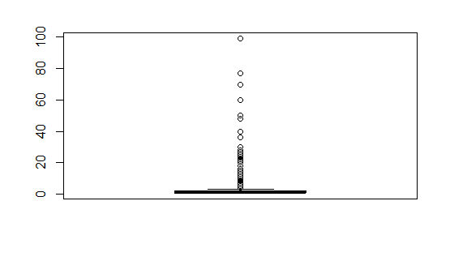

```r
boxplot(data$AVEDRNK2)
```

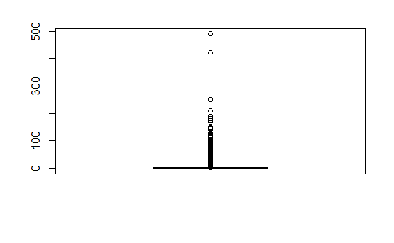

```r
#First, replace 888 with 0 and remove 777/999 responses.
data$ALCDAY5[data$ALCDAY5==888] <- 0
data$ALCDAY5[data$ALCDAY5==777] <- NA
data$ALCDAY5[data$ALCDAY5==999] <- NA

data$AVEDRNK2[data$AVEDRNK2==77] <- NA
data$AVEDRNK2[data$AVEDRNK2==99] <- NA
# data <- subset(data, data$ALCDAY5<777 | is.na(data$ALCDAY5))
# data <- subset(data, data$AVEDRNK2<77 | is.na(data$AVEDRNK2))

#Create a new column.
data$AVGDRNK <- NA

#Creating a function to calculate average alcohol consumption
#per week.
average_drink<-function(ALCDAY5, AVEDRNK2){
  ifelse(ALCDAY5==0, 0, ifelse(ALCDAY5>100 & ALCDAY5<108, (ALCDAY5 - 100)*AVEDRNK2, ifelse(ALCDAY5>200 & ALCDAY5<232, ((ALCDAY5 - 200)/4.2857)*AVEDRNK2, NA)))
}

data$AVGDRNK <- with(data, average_drink(data$ALCDAY5, data$AVEDRNK2))
boxplot(data$AVGDRNK) #may need to remove those top two outliers.
```

```r
#Removing the original variables.
data <- subset(data, select=-c(ALCDAY5, AVEDRNK2))
```

Let’s also use the same formulas above to recode STRENGTH to frequency per week.

```r
#STRENGTH; 101-199 is 1__ times per week; 201-299 is 2__ times per
#month for strength training frequency.
unique(data$STRENGTH)
```

```
 [1] 888  NA 777 107 102 101 103 105 106 204 207 205 220 104 215
[16] 210 203 201 202 225 206 230 208 212 999 125 224 260 218 114
[31] 216 112 121 221 150 245 290 299 214 213 110 227 223 228 199
[46] 209 115 235 130 229 231 170 240 244 108 211 160 111 217 222
[61] 236 116 120 118 226 109 251 122 280 264 250 128 140 132 135
[76] 219 113 288 173 275 142 232 255 127 175 270 267 119 237 242
[91] 272 136
```

```r
data$STRENGTH[data$STRENGTH==888] <- 0
data$STRENGTH[data$STRENGTH==777] <- NA
data$STRENGTH[data$STRENGTH==999] <- NA
#data <- subset(data, data$STRENGTH < 777 | is.na(data$STRENGTH))

data$STRNGTH <- NA

#Creating a function to calclulate strength training frequency in
#a week. TK UPDATE TO REMOVE 888.
avg_strength_training<-function(STRENGTH){
  ifelse(STRENGTH==0, 0, ifelse(STRENGTH>100 & STRENGTH<200, STRENGTH-100, ifelse(STRENGTH>200 & STRENGTH<300, (STRENGTH-200)/4.2857, NA)))
}

data$STRNGTH <- with(data, avg_strength_training(data$STRENGTH))

data <- subset(data, select=-c(STRENGTH))
unique(data$STRNGTH)
```

```
 [1]  0.0000000         NA  7.0000000  2.0000000  1.0000000
 [6]  3.0000000  5.0000000  6.0000000  0.9333364  1.6333388
[11]  1.1666706  4.6666822  4.0000000  3.5000117  2.3333411
[16]  0.7000023  0.2333341  0.4666682  5.8333528  1.4000047
[21]  7.0000233  1.8666729  2.8000093 25.0000000  5.6000187
[26] 14.0000467  4.2000140 14.0000000  3.7333458 12.0000000
[31] 21.0000000  4.9000163 50.0000000 10.5000350 21.0000700
[36] 23.1000770  3.2666776  3.0333434 10.0000000  6.3000210
[41]  5.3666846  6.5333551 99.0000000  2.1000070 15.0000000
[46]  8.1666939 30.0000000  6.7666892  7.2333574 70.0000000
[51]  9.3333644 10.2667009  8.0000000  2.5666752 60.0000000
[56] 11.0000000  3.9666799  5.1333504  8.4000280 16.0000000
[61] 20.0000000 18.0000000  6.0666869  9.0000000 11.9000397
[66] 22.0000000 18.6667289 14.9333831 11.6667056 28.0000000
[71] 40.0000000 32.0000000 35.0000000  4.4333481 13.0000000
[76] 20.5334018 73.0000000 17.5000583 42.0000000  7.4666916
[81] 12.8333761 27.0000000 75.0000000 16.3333878 15.6333854
[86] 19.0000000  8.6333621  9.8000327 16.8000560 36.0000000
```

Now, let’s recode some of our “88” responses (eg, “none”) responses to 0. We’ll also remove the 7/9 or 77/99 responses here as well.

```r
#CHILDREN.
unique(data$CHILDREN)
```

```
 [1] 88  1 99  2  3  5  4  6  7 10 NA 12  8  9 52 15 17
```

```r
data$CHILDREN[data$CHILDREN==88] <- 0
data$CHILDREN[data$CHILDREN==99] <- NA
unique(data$CHILDREN)
```

```
 [1]  0  1 NA  2  3  5  4  6  7 10 12  8  9 52 15 17
```

```r
#PHYSHLTH.
unique(data$PHYSHLTH)
```

```
 [1] 15 30 20 88  8 77  2 14  5 99  6 10  7  3 17  1  4 21 25 12
[21] 28 22 29 24  9 13 23 16 18 11 26 27 19 NA
```

```r
data$PHYSHLTH[data$PHYSHLTH==88] <- 0
data$PHYSHLTH[data$PHYSHLTH==77 | data$PHYSHLTH==99] <- NA
unique(data$PHYSHLTH)
```

```
 [1] 15 30 20  0  8 NA  2 14  5  6 10  7  3 17  1  4 21 25 12 28
[21] 22 29 24  9 13 23 16 18 11 26 27 19
```

```r
#MENHLTH.
unique(data$MENTHLTH)
```

```
 [1] 18 88 30  3 99  2 15 77  5  1  6 10 25  4 20  8 21 14  9  7
[21] 29 28 16 12 17 13 23 27 22 19 26 24 11
```

```r
data$MENTHLTH[data$MENTHLTH==88] <- 0
data$MENTHLTH[data$MENTHLTH==77 | data$MENTHLTH==99] <- NA
unique(data$MENTHLTH)
```

```
 [1] 18  0 30  3 NA  2 15  5  1  6 10 25  4 20  8 21 14  9  7 29
[21] 28 16 12 17 13 23 27 22 19 26 24 11
```

And finally, let’s convert all responses with “refused” or “don’t know” to NA.

```r
#SEX.
unique(data$SEX) #nothing to remove
```

```
[1] 2 1
```

```r
#MARITAL.
unique(data$MARITAL)
```

```
[1] 1 2 3 6 5 9 4
```

```r
data$MARITAL[data$MARITAL==9] <- NA

#X_Race.
unique(data$X_RACE)
```

```
[1] 1 7 9 2 3 6 8 4 5
```

```r
data$X_RACE[data$X_RACE==9] <- NA

#X_EDUCAG.
unique(data$X_EDUCAG)
```

```
[1] 2 3 1 4 9
```

```r
data$X_EDUCAG[data$X_EDUCAG==9] <- NA

#EMPLOY1.
unique(data$EMPLOY1)
```

```
[1] 8 7 2 3 5 9 1 4 6
```

```r
data$EMPLOY1[data$EMPLOY1==9] <- NA

#INCOME2.
unique(data$INCOME2)
```

```
 [1]  3 99  8 77  6  4  7  5  1  2 NA
```

```r
data$INCOME2[data$INCOME2==77 | data$INCOME2==99] <- NA

#RENTHOM1
unique(data$RENTHOM1)
```

```
[1] 1 2 3 7 9
```

```r
data$RENTHOM1[data$RENTHOM1==7 | data$RENTHOM1==9] <- NA

#VETERAN3
unique(data$VETERAN3)
```

```
[1]  2  1  9  7 NA
```

```r
data$VETERAN3[data$VETERAN3==7 | data$VETERAN3==9] <- NA

#HLTHPLN1.
unique(data$HLTHPLN1)
```

```
[1] 1 2 9 7
```

```r
data$HLTHPLN1[data$HLTHPLN1==9 | data$HLTHPLN1==7] <- NA

#MEDCOST
unique(data$MEDCOST)
```

```
[1]  2  1  7  9 NA
```

```r
data$MEDCOST[data$MEDCOST==7 | data$MEDCOST==9] <- NA

#CHECKUP1.
unique(data$CHECKUP1)
```

```
[1]  1  3  9  4  2  7  8 NA
```

```r
data$CHECKUP1[data$CHECKUP1==8] <- 0
data$CHECKUP1[data$CHECKUP1==7 | data$CHECKUP1==9] <- NA
unique(data$CHECKUP1)
```

```
[1]  1  3 NA  4  2  0
```

```r
#X _RFHYPE5.
unique(data$X_RFHYPE5)
```

```
[1] 2 1 9
```

```r
data$X_RFHYPE5[data$X_RFHYPE5==9] <- NA

#X _RFCHOL.
unique(data$X_RFCHOL)
```

```
[1]  2  1 NA  9
```

```r
data$X_RFCHOL[data$X_RFCHOL==9] <- NA

#X_MICHD.
unique(data$X_MICHD) #none to remove
```

```
[1]  2 NA  1
```

```r
#CVDSTRK3.
unique(data$CVDSTRK3)
```

```
[1] 2 1 7 9
```

```r
data$CVDSTRK3[data$CVDSTRK3==7 | data$CVDSTRK3==9] <- NA

#X_ASTHMS1.
unique(data$X_ASTHMS1)
```

```
[1] 1 3 2 9
```

```r
data$X_ASTHMS1[data$X_ASTHMS1==9] <- NA

#CHCCOPD1.
unique(data$CHCCOPD1)
```

```
[1] 1 2 7 9
```

```r
data$CHCCOPD1[data$CHCCOPD1==7 | data$CHCCOPD1==9] <- NA

#ADDEPEV2.
unique(data$ADDEPEV2)
```

```
[1] 1 2 9 7
```

```r
data$ADDEPEV2[data$ADDEPEV2==7 | data$ADDEPEV2==9] <- NA

#CHCKIDNY.
unique(data$CHCKIDNY)
```

```
[1] 2 7 1 9
```

```r
data$CHCKIDNY[data$CHCKIDNY==7 | data$CHCKIDNY==9] <- NA

#DIABETE3.
unique(data$DIABETE3)
```

```
[1]  3  1  4  2  7 NA  9
```

```r
data$DIABETE3[data$DIABETE3==7 | data$DIABETE3==9] <- NA

#X_SMOKER3.
unique(data$X_SMOKER3)
```

```
[1] 3 9 4 1 2
```

```r
data$X_SMOKER3[data$X_SMOKER3==9] <- NA

#QLACTLM2.
unique(data$QLACTLM2)
```

```
[1]  1  2 NA  7  9
```

```r
data$QLACTLM2[data$QLACTLM2==7 | data$QLACTLM2==9] <- NA

#USEEQUIP.
unique(data$USEEQUIP)
```

```
[1]  1  2 NA  9  7
```

```r
data$USEEQUIP[data$USEEQUIP==7 | data$USEEQUIP==9] <- NA

#BLIND.
unique(data$BLIND)
```

```
[1]  2  1  7 NA  9
```

```r
data$BLIND[data$BLIND==7 | data$BLIND==9] <- NA

#DECIDE.
unique(data$DECIDE)
```

```
[1]  2  1 NA  9  7
```

```r
data$DECIDE[data$DECIDE==7 | data$DECIDE==9] <- NA

#EXRACT11.
unique(data$EXRACT11)
```

```
 [1] NA 18 64 98  6 54 15  2 11 67 14 75  7 72 28 57 66 76 73 19
[21] 69 61  9 36 20 37 31 25 40 32 35 77 58 22 26 16 60 24 63 99
[41] 49 13 33 55 47 48 74 46  1 52 30 10  4 59 34  5 21 50 68 71
[61]  8 56 44 17 23 12 51 53 62 43 42 27 39  3 41 38 45 29
```

```r
data$EXRACT11[data$EXRACT11==77 | data$EXRACT11==99] <- NA
unique(data$EXRACT11)
```

```
 [1] NA 18 64 98  6 54 15  2 11 67 14 75  7 72 28 57 66 76 73 19
[21] 69 61  9 36 20 37 31 25 40 32 35 58 22 26 16 60 24 63 49 13
[41] 33 55 47 48 74 46  1 52 30 10  4 59 34  5 21 50 68 71  8 56
[61] 44 17 23 12 51 53 62 43 42 27 39  3 41 38 45 29
```

```r
#FLUSHOT6.
unique(data$FLUSHOT6)
```

```
[1]  1 NA  2  7  9
```

```r
data$FLUSHOT6[data$FLUSHOT6==7 | data$FLUSHOT6==9] <- NA
```

Now, for our target attribute (X_RFHLTH) let’s remove BOTH the ‘NA’ and ‘9’ values.

```r
#X_RFHLTH. Subset function removes all NA in our target attribute.
table(data$X_RFHLTH, useNA="ifany")
```

```
     1      2      9
155337  46330    745
```

```r
data <- subset(data, data$X_RFHLTH<9)
table(data$X_RFHLTH, useNA="ifany")
```

```
     1      2
155337  46330
```

Let’s take a look at our proportions of NA values within each column of the dataset.

```r
lapply(data, function(var) {(sum(is.na(var))/length(var))*100})
```

```
$SEX
[1] 0

$MARITAL
[1] 0.4710736

$CHILDREN
[1] 0.3639663

$X_RACE
[1] 1.583799

$X_AGEG5YR
[1] 0

$X_BMI5
[1] 6.750733

$X_EDUCAG
[1] 0.3451234

$EMPLOY1
[1] 0.5880982

$INCOME2
[1] 21.00393

$RENTHOM1
[1] 0.5623131

$VETERAN3
[1] 0.1264461

$X_RFHLTH
[1] 0

$PHYSHLTH
[1] 3.052061

$MENTHLTH
```

[output cut: 73 more lines]

```

$FLUSHOT6
[1] 8.689572

$ADULT
[1] 0.6565278

$CNCER
[1] 0.4760323

$AVGDRNK
[1] 5.194702

$STRNGTH
[1] 8.812052
```

```r
#INCOME and EXRACT11 can be recoded since they are categorical. We'll
#leave PA1MIN_ and PA1VIGM_ until we have a better understanding of
#the relationship with X_RFHLTH.
```

```r
#Recoding the NA values in INCOME and EXTRACT.
data$INCOME2[is.na(data$INCOME2)]<-0
data$EXRACT11[is.na(data$EXRACT11)]<-0
```

```r
#Number of respondents with 50% NA values (31 missing columns).
sum(rowSums(is.na(data))>=24) # 9
```

```
[1] 4
```

```r
#Number of respondents with 40% or more NA values (25 columns).
sum(rowSums(is.na(data))>=19) # 217
```

```
[1] 59
```

```r
#Number of respondents with 30% or more NA values (19 columns).
sum(rowSums(is.na(data))>=14) # 4366
```

```
[1] 3184
```

```r
#Number of respondents with 15% or more NA values (6 columns)
sum(rowSums(is.na(data))>5) # 19873
```

```
[1] 15265
```

```r
data_clean<-data[rowSums(is.na(data))<5,] #data with less than 15% #missing values in each row
lapply(data_clean, function(var) {(sum(is.na(var))/length(var))*100})
```

```
$SEX
[1] 0

$MARITAL
[1] 0.3078771

$CHILDREN
[1] 0.09880452

$X_RACE
[1] 1.249522

$X_AGEG5YR
[1] 0

$X_BMI5
[1] 4.588133

$X_EDUCAG
[1] 0.1872373

$EMPLOY1
[1] 0.354277

$INCOME2
[1] 0

$RENTHOM1
[1] 0.363557

$VETERAN3
[1] 0.04367051

$X_RFHLTH
[1] 0

$PHYSHLTH
[1] 2.331459

$MENTHLTH
```

[output cut: 73 more lines]

```

$FLUSHOT6
[1] 1.62891

$ADULT
[1] 0.662154

$CNCER
[1] 0.3892134

$AVGDRNK
[1] 1.44604

$STRNGTH
[1] 1.649653
```

OK. Let’s clean our numeric variables. Our numeric attributes include CHILDREN, ADULT, X_BMI5, PHYSHLTH, MENHLTH, AVGDRNK, X_FRUTSUM, BEANDAY_, X_VEGESUM, PA1MIN, STRENGTH, PA1VIGM_. The rule of thumb is that outliers in the 99th percentiles (eg, top and bottom 1% of the data) will be brought into the 99th percentile. Exceptions will be allowed if the value of the 99th percentile seems plausible (eg, plausible to eat or drink a certain amount).

```r
str(data_clean) #BMI, FRUT, VEG, BEAN variables have incorrect values
```

```
'data.frame':   183190 obs. of  43 variables:
 $ SEX      : num  2 2 2 2 2 1 1 2 2 2 ...
 $ MARITAL  : num  1 1 1 3 3 1 1 1 3 3 ...
 $ CHILDREN : num  0 1 0 0 0 0 0 0 0 0 ...
 $ X_RACE   : num  1 1 1 1 7 1 1 1 1 1 ...
 $ X_AGEG5YR: num  9 9 9 11 11 13 10 9 13 11 ...
 $ X_BMI5   : num  4018 2819 2437 2652 2389 ...
 $ X_EDUCAG : num  2 2 3 1 3 1 4 4 3 2 ...
 $ EMPLOY1  : num  8 8 8 2 7 3 7 7 8 5 ...
 $ INCOME2  : num  3 8 0 6 4 3 8 7 0 4 ...
 $ RENTHOM1 : num  1 1 1 1 1 1 1 1 1 1 ...
 $ VETERAN3 : num  2 2 2 2 2 1 2 2 2 2 ...
 $ X_RFHLTH : num  2 2 2 1 1 2 1 1 2 1 ...
 $ PHYSHLTH : num  15 30 20 0 0 8 2 14 0 0 ...
 $ MENTHLTH : num  18 30 0 0 3 0 0 0 0 0 ...
```

[output cut: 29 more lines]

```r
data_clean$X_BMI5 <- data_clean$X_BMI5/100
data_clean$X_FRUTSUM <- data_clean$X_FRUTSUM/100
data_clean$X_VEGESUM <- data_clean$X_VEGESUM/100
data_clean$BEANDAY_ <- data_clean$BEANDAY_/100
```

CHILDREN.

```r
#CHILDREN.
summary(data_clean$CHILDREN) #noticeable skew with outliers
```

```
    Min.  1st Qu.   Median     Mean  3rd Qu.     Max.     NA's
 0.00000  0.00000  0.00000  0.06801  0.00000 17.00000      181
```

```r
#Winsorizing all outliers.
quantile(data_clean$CHILDREN, .999, na.rm=TRUE) #99th percentile #seemed low, so we're using the .1th percentile
```

```
99.9%
    4
```

```r
data_clean$CHILDREN[data_clean$CHILDREN>4]<-4
unique(data_clean$CHILDREN)
```

```
[1]  0  1  2  3 NA  4
```

```r
#Assessing cleaned data.
summary(data_clean$CHILDREN)
```

```
   Min. 1st Qu.  Median    Mean 3rd Qu.    Max.    NA's
0.00000 0.00000 0.00000 0.06665 0.00000 4.00000     181
```

```r
sd(data_clean$CHILDREN, na.rm = TRUE)
```

```
[1] 0.3641822
```

```r
library(modeest) #mode
mfv(data_clean$CHILDREN)
```

```
[1] 0
```

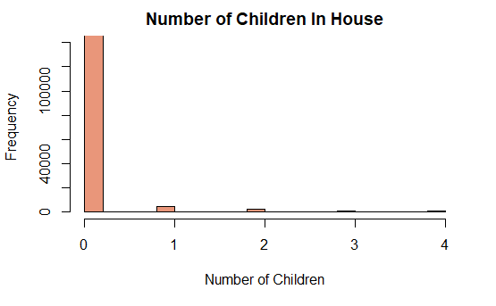

```r
hist(data_clean$CHILDREN,
     col = "darksalmon",
     xlim=c(0,4),
     ylim=c(0,140000),
     main = "Number of Children In House",
     xlab="Number of Children")
```

ADULT.

```r
#ADULT.
summary(data_clean$ADULT)
```

```
   Min. 1st Qu.  Median    Mean 3rd Qu.    Max.    NA's
  1.000   1.000   2.000   1.696   2.000  60.000    1213
```

```r
#Converting outliers to "4" which from now on will mean 4 or more
#adults.
quantile(data_clean$ADULT, .99, na.rm=TRUE) #4
```

```
99%
  4
```

```r
data_clean$ADULT[data_clean$ADULT>4]<-4
unique(data_clean$ADULT)
```

```
[1]  3  2  1  4 NA
```

```r
#Assessing cleaned data.
summary(data_clean$ADULT) #Mean = 1.7; Median = 2.0
```

```
   Min. 1st Qu.  Median    Mean 3rd Qu.    Max.    NA's
  1.000   1.000   2.000   1.686   2.000   4.000    1213
```

```r
sd(data_clean$ADULT, na.rm = TRUE) #SD =
```

```
[1] 0.6879941
```

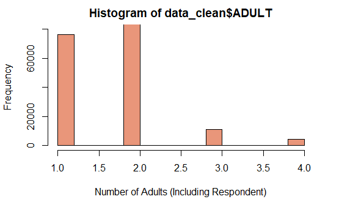

```r
hist(data_clean$ADULT,
     col = "darksalmon",
     xlim=c(1,4),
     ylim=c(0,80000),
     xlab="Number of Adults (Including Respondent)")
```

BMI.

```r
#BMI.
summary(data_clean$X_BMI5)
```

```
   Min. 1st Qu.  Median    Mean 3rd Qu.    Max.    NA's
  12.11   23.96   27.05   27.87   30.68   97.65    8405
```

```r
#Winsorizing.
quantile(data_clean$X_BMI5, c(.01, .99), na.rm=TRUE)
```

```
   1%   99%
17.85 46.59
```

```r
data_clean$X_BMI5[data_clean$X_BMI5<18.02]<-17.92
data_clean$X_BMI5[data_clean$X_BMI5>44.08]<-46.48

#Assessing distribution.
mfv(data_clean$X_BMI5, na_rm = TRUE)
```

```
[1] 46.48
```

```r
sd(data_clean$X_BMI5, na.rm = TRUE)
```

```
[1] 5.554695
```

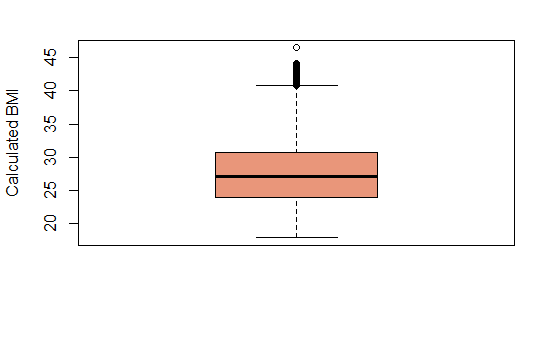

```r
boxplot(data_clean$X_BMI5,
     col = "darksalmon",
     ylab="Calculated BMI")
```

PHYSHLTH.

```r
summary(data_clean$PHYSHLTH)
```

```
   Min. 1st Qu.  Median    Mean 3rd Qu.    Max.    NA's
  0.000   0.000   0.000   5.005   4.000  30.000    4271
```

```r
quantile(data_clean$PHYSHLTH, .99, na.rm=TRUE) #left as is
```

```
99%
 30
```

```r
mfv(data_clean$PHYSHLTH, na_rm = TRUE)
```

```
[1] 0
```

```r
sd(data_clean$PHYSHLTH, na.rm = TRUE)
```

```
[1] 9.53507
```

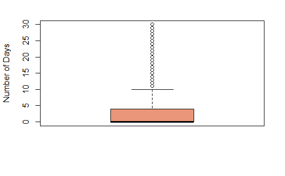

```r
boxplot(data_clean$PHYSHLTH,
     col = "darksalmon",
     ylab="Number of Days") #may switch to violin plot
```

MENHLTH.

```r
summary(data_clean$MENTHLTH)
```

```
   Min. 1st Qu.  Median    Mean 3rd Qu.    Max.    NA's
    0.0     0.0     0.0     2.5     0.0    30.0    2704
```

```r
quantile(data_clean$MENTHLTH, .99, na.rm=TRUE) #left as is
```

```
99%
 30
```

```r
mfv(data_clean$MENTHLTH, na_rm = TRUE)
```

```
[1] 0
```

```r
sd(data_clean$MENTHLTH, na.rm = TRUE)
```

```
[1] 6.81447
```

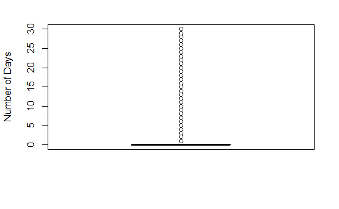

```r
boxplot(data_clean$MENTHLTH,
     col = "darksalmon",
     ylab="Number of Days") #may switch to violin plot
```

AVGDRINK.

```r
summary(data_clean$AVGDRNK)
```

```
   Min. 1st Qu.  Median    Mean 3rd Qu.    Max.    NA's
  0.000   0.000   0.000   2.233   1.633 490.000    2649
```

```r
quantile(data_clean$AVGDRNK, .99, na.rm=TRUE)
```

```
     99%
23.33341
```

```r
summary(data_clean$AVGDRNK)
```

```
   Min. 1st Qu.  Median    Mean 3rd Qu.    Max.    NA's
  0.000   0.000   0.000   2.233   1.633 490.000    2649
```

```r
mfv(data_clean$AVGDRNK)
```

```
[1] 0
```

```r
sd(data_clean$AVGDRNK, na.rm = TRUE)
```

```
[1] 6.714709
```

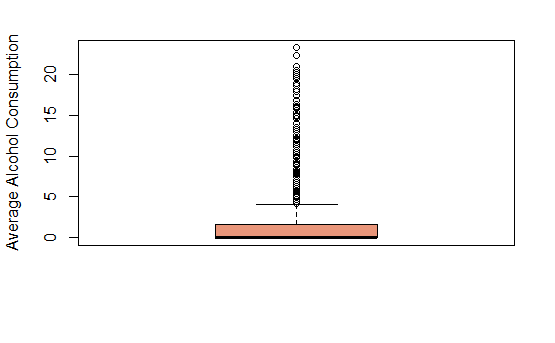

```r
data_clean$AVGDRNK[data_clean$AVGDRNK>23.33]<-23.33
boxplot(data_clean$AVGDRNK,
     col = "darksalmon",
     ylab="Average Alcohol Consumption")
```

FRUIT.

```r
summary(data_clean$X_FRUTSUM)
```

```
   Min. 1st Qu.  Median    Mean 3rd Qu.    Max.    NA's
  0.000   0.600   1.070   1.394   2.000 129.000    4987
```

```r
quantile(data_clean$X_FRUTSUM, .999, na.rm=TRUE) #7 seems low; using # the 0.1th percentile
```

```
99.9%
    8
```

```r
data_clean$X_FRUTSUM[data_clean$X_FRUTSUM>8]<-8


#Descriptives.
summary(data_clean$X_FRUTSUM)
```

```
   Min. 1st Qu.  Median    Mean 3rd Qu.    Max.    NA's
  0.000   0.600   1.070   1.384   2.000   8.000    4987
```

```r
mfv(data_clean$X_FRUTSUM)
```

```
[1] NA
```

```r
sd(data_clean$X_FRUTSUM, na.rm = TRUE)
```

```
[1] 1.079639
```

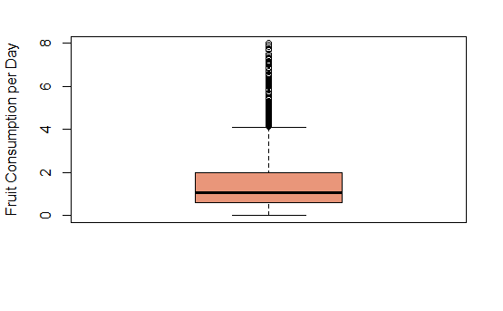

```r
boxplot(data_clean$X_FRUTSUM,
     col = "darksalmon",
     ylab = "Fruit Consumption per Day")
```

VEG.

```r
summary(data_clean$X_VEGESUM)
```

```
   Min. 1st Qu.  Median    Mean 3rd Qu.    Max.    NA's
  0.000   1.130   1.700   1.922   2.430 199.290    7310
```

```r
quantile(data_clean$X_VEGESUM, .99, na.rm=TRUE) #seems low, using
```

```
 99%
6.42
```

```r
#the 0.1th percentile
data_clean$X_VEGESUM[data_clean$X_VEGESUM>11]<-11

#Descriptives.
summary(data_clean$X_VEGESUM)
```

```
   Min. 1st Qu.  Median    Mean 3rd Qu.    Max.    NA's
  0.000   1.130   1.700   1.915   2.430  11.000    7310
```

```r
mfv(data_clean$X_VEGESUM, na_rm = TRUE)
```

```
[1] 2
```

```r
sd(data_clean$X_VEGESUM, na.rm = TRUE)
```

```
[1] 1.252121
```

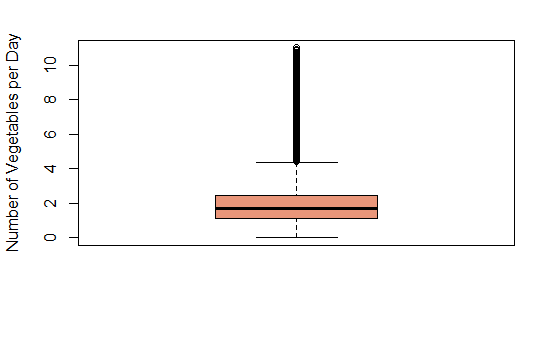

```r
boxplot(data_clean$X_VEGESUM,
     col = "darksalmon",
     ylab="Number of Vegetables per Day")
```

BEAN.

```r
summary(data_clean$BEANDAY_)
```

```
   Min. 1st Qu.  Median    Mean 3rd Qu.    Max.    NA's
 0.0000  0.0700  0.1400  0.2661  0.3300 15.0000    3042
```

```r
quantile(data_clean$BEANDAY_, .999, na.rm=TRUE) #seems low; using .1th #percentile
```

```
99.9%
    4
```

```r
data_clean$BEANDAY_[data_clean$BEANDAY_>4]<-4

#Descriptives.
summary(data_clean$BEANDAY_)
```

```
   Min. 1st Qu.  Median    Mean 3rd Qu.    Max.    NA's
 0.0000  0.0700  0.1400  0.2649  0.3300  4.0000    3042
```

```r
mfv(data_clean$BEANDAY_, na_rm = TRUE)
```

```
[1] 0
```

```r
sd(data_clean$BEANDAY_, na.rm = TRUE)
```

```
[1] 0.3539
```

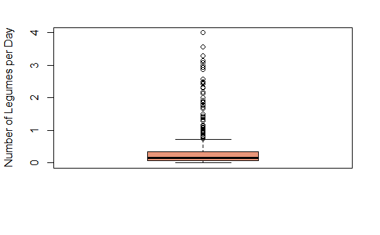

```r
boxplot(data_clean$BEANDAY_,
     col = "darksalmon",
     ylab="Number of Legumes per Day")
```

PA.

```r
data_clean$PA1MIN_ <- data_clean$PA1MIN_/7 #change to per day

summary(data_clean$PA1MIN_) #values seem OK
```

```
   Min. 1st Qu.  Median    Mean 3rd Qu.    Max.    NA's
   0.00   22.00   50.00   85.39  100.00 5502.86   54976
```

```r
quantile(data_clean$PA1MIN_, .99, na.rm=TRUE)
```

```
99%
600
```

```r
data_clean$PA1MIN_[data_clean$PA1MIN_>600]<-600

#Descriptives.
summary(data_clean$PA1MIN_) #values seem OK
```

```
   Min. 1st Qu.  Median    Mean 3rd Qu.    Max.    NA's
   0.00   22.00   50.00   82.93  100.00  600.00   54976
```

```r
mfv(data_clean$PA1MIN_)
```

```
[1] NA
```

```r
sd(data_clean$PA1MIN_, na.rm = TRUE)
```

```
[1] 102.7176
```

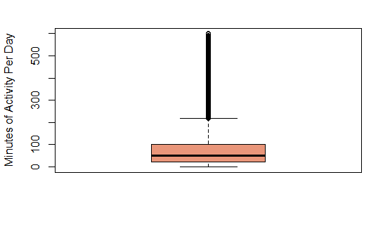

```r
boxplot(data_clean$PA1MIN_,
     col = "darksalmon",
     ylab="Minutes of Activity Per Day")
```

STRGNTH.

```r
summary(data_clean$STRNGTH) #values seem OK
```

```
   Min. 1st Qu.  Median    Mean 3rd Qu.    Max.    NA's
  0.000   0.000   0.000   1.071   1.167  99.000    3022
```

```r
#Recoding to "yes" and "no" of 1 and 2.
table(data_clean$STRNGTH)
```

```
                0 0.233334111113704 0.466668222227407
           122182              1119              2008
0.700002333341111 0.933336444454815                 1
             1308              1565              5411
 1.16667055556852  1.40000466668222  1.63333877779593
             1561               606               249
 1.86667288890963                 2  2.10000700002333
              919              9077                92
 2.33334111113704  2.56667522225074  2.80000933336444
             1660                 9               856
                3  3.03334344447815  3.26667755559185
            10984                25               107
 3.50001166670556  3.73334577781926  3.96667988893296
             1600               155                13
                4  4.20001400004667  4.43334811116037
             3292                43                 3
 4.66668222227407  4.90001633338778                 5
             1222                41              3733
 5.13335044450148  5.36668455561519  5.60001866672889
               22                10                56
 5.83335277784259                 6   6.0666868889563
              492              1167                30
    6.30002100007   6.5333551111837  6.76668922229741
               32                91                17
                7  7.00002333341111  7.23335744452481
             5520              2202                22
 7.46669155563852                 8  8.16669388897963
                1                39                 3
 8.63336211120704                 9  9.33336444454815
                1                 9                11
 9.80003266677556                10   10.266700889003
                2                77                 1
 10.5000350001167                11  11.6667055556852
                9                 3                 9
 11.9000396667989                12  12.8333761112537
                1                29                 1
               13                14  14.0000466668222
                4               240                49
  14.933383111277                15  15.6333854446181
                1                14                 1
               16  16.3333877779593  16.8000560001867
                2                 2                 1
 17.5000583335278                18  18.6667288890963
                1                 6                 2
               19                20  20.5334017780059
                2                22                 2
               21  21.0000700002333                22
               38                11                 2
 23.1000770002567                25                27
                7                 7                 1
               28                30                32
                7                16                 1
               35                36                40
                5                 1                 3
               42                50                60
                1                 5                 2
               70                73                75
                4                 1                 1
               99
                9
```

```r
data_clean$STRNGTH[data_clean$STRNGTH>0]<-1
data_clean$STRNGTH[data_clean$STRNGTH==0]<-2
table(data_clean$STRNGTH)
```

```
     1      2
 57986 122182
```

```r
table(data_clean$STRNGTH, useNA = "ifany")
```

```
     1      2   <NA>
 57986 122182   3022
```

```r
mfv(data_clean$STRNGTH)
```

```
[1] 2
```

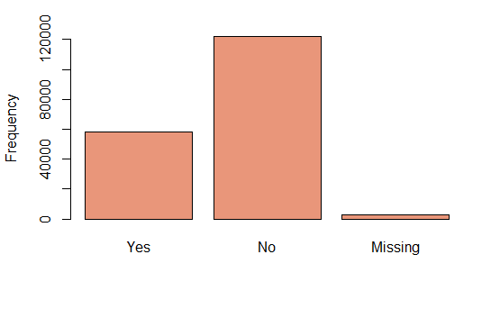

```r
barplot(table(data_clean$STRNGTH, useNA = "ifany"),
     col = "darksalmon",
     ylab="Frequency",
     names.arg=c("Yes", "No", "Missing"))
```

PA1VIGM.

```r
summary(data_clean$PA1VIGM_) #values seem OK
```

```
   Min. 1st Qu.  Median    Mean 3rd Qu.    Max.    NA's
   0.00    0.00   12.86   30.10   36.00  274.28   54479
```

```r
data_clean$PA1VIGM_ <- data_clean$PA1VIGM_/7 #to per day
quantile(data_clean$PA1VIGM_, .99, na.rm=TRUE)
```

```
     99%
39.18286
```

```r
data_clean$PA1VIGM_[data_clean$PA1VIGM_>274.28]<-274.28

#Descriptives.
summary(data_clean$PA1VIGM_) #values seem OK
```

```
   Min. 1st Qu.  Median    Mean 3rd Qu.    Max.    NA's
   0.00    0.00    1.84    4.30    5.14   39.18   54479
```

```r
mfv(data_clean$PA1VIGM_)
```

```
[1] NA
```

```r
sd(data_clean$PA1VIGM_, na.rm = TRUE)
```

```
[1] 6.894619
```

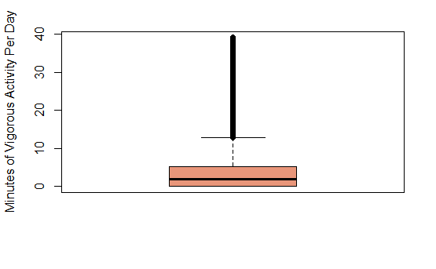

```r
boxplot(data_clean$PA1VIGM_,
     col = "darksalmon",
     ylab="Minutes of Vigorous Activity Per Day")
```

Now, Let’s run through some descriptives of our categorical variables.

```r
str(data_clean)
```

```
'data.frame':   183190 obs. of  43 variables:
 $ SEX      : num  2 2 2 2 2 1 1 2 2 2 ...
 $ MARITAL  : num  1 1 1 3 3 1 1 1 3 3 ...
 $ CHILDREN : num  0 1 0 0 0 0 0 0 0 0 ...
 $ X_RACE   : num  1 1 1 1 7 1 1 1 1 1 ...
 $ X_AGEG5YR: num  9 9 9 11 11 13 10 9 13 11 ...
 $ X_BMI5   : num  40.2 28.2 24.4 26.5 23.9 ...
 $ X_EDUCAG : num  2 2 3 1 3 1 4 4 3 2 ...
 $ EMPLOY1  : num  8 8 8 2 7 3 7 7 8 5 ...
 $ INCOME2  : num  3 8 0 6 4 3 8 7 0 4 ...
 $ RENTHOM1 : num  1 1 1 1 1 1 1 1 1 1 ...
 $ VETERAN3 : num  2 2 2 2 2 1 2 2 2 2 ...
 $ X_RFHLTH : num  2 2 2 1 1 2 1 1 2 1 ...
 $ PHYSHLTH : num  15 30 20 0 0 8 2 14 0 0 ...
 $ MENTHLTH : num  18 30 0 0 3 0 0 0 0 0 ...
```

[output cut: 29 more lines]

SEX.

```r
#descriptives.
table(data_clean$SEX, useNA = "ifany")
```

```
     1      2
 72911 110279
```

```r
mfv(data_clean$SEX)
```

```
[1] 2
```

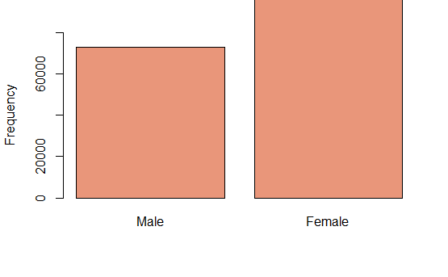

```r
#visual
barplot(table(data_clean$SEX,
              useNA = "ifany"),
col="darksalmon",
        names.arg= c("Male", "Female"),
        ylab = "Frequency",
        ylim=c(0,80000))
```

MARITAL.

```r
#MARITAL.
table(data_clean$MARITAL, useNA = "ifany")
```

```
    1     2     3     4     5     6  <NA>
95800 27218 45116  2224 10452  1816   564
```

```r
mfv(data_clean$MARITAL)
```

```
[1] 1
```

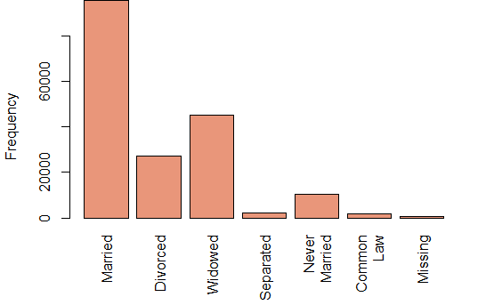

```r
barplot(table(data_clean$MARITAL,
              useNA = "ifany"),
col="darksalmon",
las=3,
        names.arg= c("Married", "Divorced", "Widowed", "Separated",
                      "Never\nMarried", "Common\nLaw", "Missing"),
        ylab = "Frequency",
        ylim=c(0,80000))
```

RACE.

```r
table(data_clean$X_RACE, useNA = "ifany")
```

```
     1      2      3      4      5      6      7      8   <NA>
154109  11739   1864   2036    252    714   2421   7766   2289
```

```r
mfv(data_clean$X_RACE)
```

```
[1] 1
```

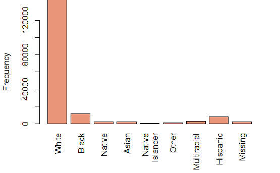

```r
barplot(table(data_clean$X_RACE,
              useNA = "ifany"),
col="darksalmon",
        names.arg= c("White", "Black", "Native", "Asian", "Native\nIslander","Other","Multiracial", "Hispanic", "Missing"),
las=3,
        ylab = "Frequency",
        ylim=c(0,120000))
```

AGE.

```r
table(data_clean$X_AGEG5YR, useNA = "ifany")
```

```
    9    10    11    12    13
45798 45456 35003 25393 31540
```

```r
mfv(data_clean$X_AGEG5YR)
```

```
[1] 9
```

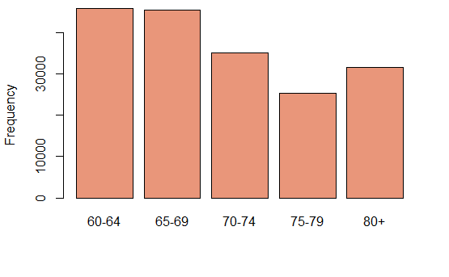

```r
barplot(table(data_clean$X_AGEG5YR,
              useNA = "ifany"),
        col="darksalmon",
        names.arg= c("60-64", "65-69", "70-74","75-79", "80+"),
        ylab = "Frequency",
        ylim=c(0,40000))
```

EDUCATION.

```r
table(data_clean$X_EDUCAG, useNA = "ifany")
```

```
    1     2     3     4  <NA>
14472 53280 49063 66032   343
```

```r
mfv(data_clean$X_EDUCAG)
```

```
[1] 4
```

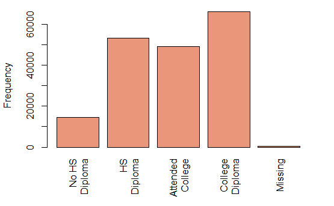

```r
barplot(table(data_clean$X_EDUCAG,
              useNA = "ifany"),
        col="darksalmon",
        las=3,
        names.arg=c("No HS\nDiploma", "HS\nDiploma","Attended\nCollege", "College\nDiploma", "Missing"),
        ylab = "Frequency",
        ylim=c(0,60000))
```

EMPLOYMENT.

```r
table(data_clean$EMPLOY1, useNA = "ifany")
```

```
     1      2      3      4      5      6      7      8   <NA>
 31805  12367   2151   1291   9880    148 113590  11309    649
```

```r
#Need to condense some of these categories.
data_clean$EMPLOY1[data_clean$EMPLOY1==1 | data_clean$EMPLOY1==2] <- 1
data_clean$EMPLOY1[data_clean$EMPLOY1==3]<- 2
data_clean$EMPLOY1[data_clean$EMPLOY1==4]<- 2
data_clean$EMPLOY1[data_clean$EMPLOY1==8]<- 2
data_clean$EMPLOY1[data_clean$EMPLOY1==7]<-3
data_clean$EMPLOY1[data_clean$EMPLOY1==5 | data_clean$EMPLOY1==6]<- 4

#Descriptives.
table(data_clean$EMPLOY1, useNA = "ifany")
```

```
     1      2      3      4   <NA>
 44172  14751 113590  10028    649
```

```r
mfv(data_clean$EMPLOY1)
```

```
[1] 3
```

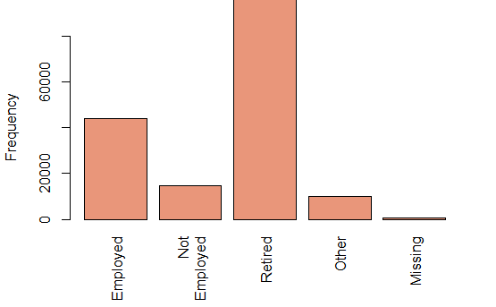

```r
#Visual.
barplot(table(data_clean$EMPLOY1,
              useNA = "ifany"),
        col="darksalmon",
        las=3,
        names.arg= c("Employed", "Not\nEmployed", "Retired","Other", "Missing"),
        ylab = "Frequency",
        ylim=c(0,80000))
```

INCOME.

```r
table(data_clean$INCOME2, useNA = "ifany")
```

```
    0     1     2     3     4     5     6     7     8
34021  5930  9326 12287 15373 19637 24743 24515 37358
```

```r
mfv(data_clean$INCOME2)
```

```
[1] 8
```

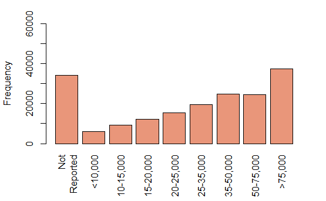

```r
barplot(table(data_clean$INCOME2,
              useNA = "ifany"),
        las=3,
        col="darksalmon",
        names.arg= c( "Not\nReported", "<10,000", "10-15,000", "15-20,000","20-25,000", "25-35,000", "35-50,000","50-75,000", ">75,000"),
        ylab = "Frequency",
        ylim=c(0,60000))
```

RENTHOME.

```r
table(data_clean$RENTHOM1, useNA = "ifany")
```

```
     1      2      3   <NA>
153675  24629   4220    666
```

```r
#Condensing down to two categories.
data_clean$RENTHOM1[data_clean$RENTHOM1==2 | data_clean$RENTHOM1==3]<-2

table(data_clean$RENTHOM1, useNA = "ifany")
```

```
     1      2   <NA>
153675  28849    666
```

```r
mfv(data_clean$RENTHOM1)
```

```
[1] 1
```

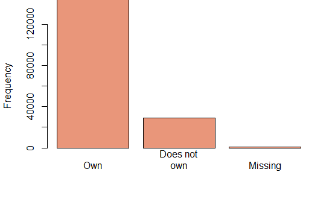

```r
barplot(table(data_clean$RENTHOM1,
              useNA = "ifany"),
       col="darksalmon",
        names.arg= c("Own", "Does not\nown", "Missing"),
        ylab = "Frequency",
        ylim=c(0,120000))
```

VETERAN.

```r
table(data_clean$VETERAN3, useNA = "ifany")
```

```
     1      2   <NA>
 35977 147133     80
```

```r
mfv(data_clean$VETERAN3)
```

```
[1] 2
```

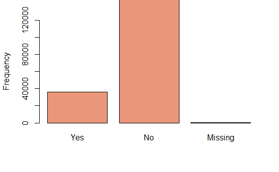

```r
barplot(table(data_clean$VETERAN3,
              useNA = "ifany"),
        col="darksalmon",
        names.arg= c("Yes", "No", "Missing"),
        ylab = "Frequency",
        ylim=c(0,120000))
```

GENHLTH.

```r
table(data_clean$X_RFHLTH)
```

```
     1      2
142392  40798
```

```r
mfv(data_clean$X_RFHLTH)
```

```
[1] 1
```

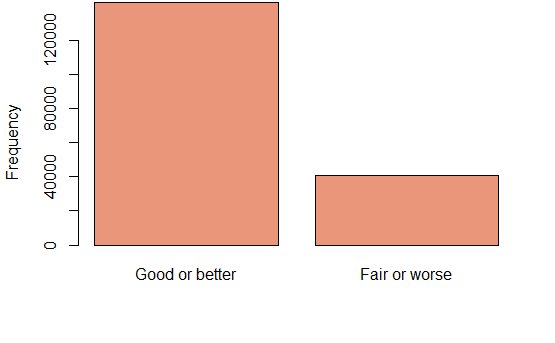

```r
barplot(table(data_clean$X_RFHLTH,
              useNA = "ifany"),
        col="darksalmon",
        names.arg= c("Good or better", "Fair or worse"),
        ylab = "Frequency",
        ylim=c(0,120000))
```

HLTHPLN1.

```r
table(data_clean$HLTHPLN1, useNA = "ifany")
```

```
     1      2   <NA>
178443   4479    268
```

```r
mfv(data_clean$HLTHPLN1)
```

```
[1] 1
```

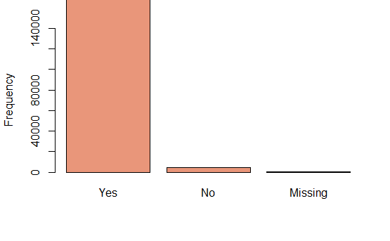

```r
barplot(table(data_clean$HLTHPLN1,
              useNA = "ifany"),
        col="darksalmon",
        names.arg= c("Yes", "No", "Missing"),
        ylab = "Frequency",
        ylim=c(0,140000))
```

MEDCOST.

```r
table(data_clean$MEDCOST, useNA = "ifany")
```

```
     1      2   <NA>
  9632 173215    343
```

```r
mfv(data_clean$MEDCOST)
```

```
[1] 2
```

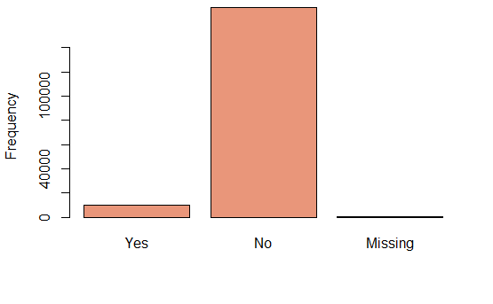

```r
barplot(table(data_clean$MEDCOST,
              useNA = "ifany"),
       col="darksalmon",
        names.arg= c("Yes", "No", "Missing"),
       ylab = "Frequency",
        ylim=c(0,150000))
```

CHECKUP.

```r
table(data_clean$CHECKUP1, useNA = "ifany")
```

```
     0      1      2      3      4   <NA>
   963 153432  14463   6304   6335   1693
```

```r
#Condensing down to "Within a year" and "more than 1 year".
data_clean$CHECKUP1[data_clean$CHECKUP1==0 | data_clean$CHECKUP1==2 | data_clean$CHECKUP1==3 | data_clean$CHECKUP1==4]<-2

#Descriptives.
table(data_clean$CHECKUP1, useNA = "ifany")
```

```
     1      2   <NA>
153432  28065   1693
```

```r
mfv(data_clean$CHECKUP1)
```

```
[1] 1
```

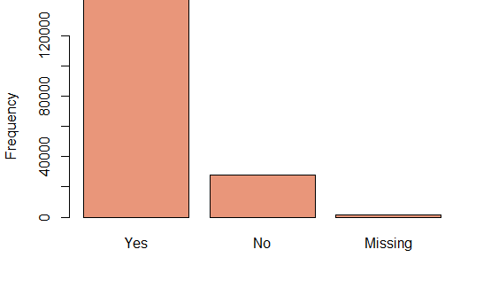

```r
barplot(table(data_clean$CHECKUP1,
              useNA = "ifany"),
        col="darksalmon",
        names.arg= c("Yes", "No", "Missing"),
        ylab = "Frequency",
        ylim=c(0,120000))
```

FLUSHOT6.

```r
table(data_clean$FLUSHOT6, useNA = "ifany")
```

```
     1      2   <NA>
107566  72640   2984
```

```r
mfv(data_clean$FLUSHOT6)
```

```
[1] 1
```

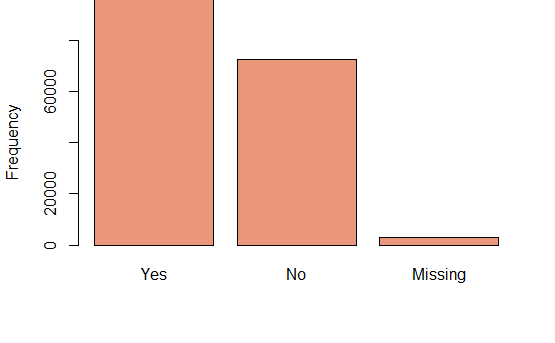

```r
barplot(table(data_clean$FLUSHOT6,
              useNA = "ifany"),
        col="darksalmon",
        names.arg= c("Yes", "No", "Missing"),
        ylab = "Frequency",
        ylim=c(0,80000))
```

X_RFHYPE5 (BLOOD PRESSURE).

```r
table(data_clean$X_RFHYPE5, useNA = "ifany")
```

```
     1      2   <NA>
 76859 105905    426
```